# Which London Underground line should trial a new cooling system?

Jashwanth Anand Shankar

```r
options(digits = 4)
knitr::opts_chunk$set(echo = TRUE)
library(tidyverse)
library(gridExtra)
library(ggplot2)
library(kableExtra)
library(knitr)
library(data.table)
```

## Use of Generative AI

Generative AI (Google Gemini) was used for code suggestions and proofreading. All analysis, interpretation and conclusions are my own.

## Problem Statement: Evaluating London Underground Temperatures for Cooling System Trials

This analysis looks at monthly average temperatures recorded across London Underground lines to support a policy decision on where to trial a new air‑cooling system. The task requires checking the integrity of the dataset, summarizing key statistics for each line, and comparing distributions of temperature values. Particular emphasis is placed on the Bakerloo and Central Lines, both overall and during summer months, to determine which line would be the most appropriate candidate for the cooling system pilot.

## Data Dictionary

The variables from the data provided are described in the table below

| Variable | Description |
| --- | --- |
| ID | A unique identifier for each monthly temperature reading. |
| Year | The year the temperature was recorded. |
| Month | The calendar month the temperature was recorded (e.g., “January”). |
| Line | The specific London Underground line being measured. |
| Temp | The average temperature recorded for that line, month, and year. |

# Section 1

## Load data

```r
# Load temperature data from the provided CSV file.
# This dataset likely contains readings from London Underground stations.
london_underground <- read_csv("Underground.csv")
# Display the first few rows to verify successful import and inspect structure.
head(london_underground)
```

```
## # A tibble: 6 × 5
##   ID        Year Month   Line        Temp
##   <chr>    <dbl> <chr>   <chr>      <dbl>
## 1 TFL00001  2013 January Bakerloo    22.0
## 2 TFL00002  2013 January Central     21
## 3 TFL00003  2013 January Jubilee     16.4
## 4 TFL00004  2013 January Northern    19.5
## 5 TFL00005  2013 January Piccadilly  19.3
## 6 TFL00006  2013 January Victoria    18.4
```

## Data Structure and Validation

We conduct initial exploratory checks to validate the structure, content, and integrity of the dataset, ensuring a clear understanding of the data provided before proceeding with analysis.

```r
# Inspect the structure of the imported dataset.
# This is a fundamental first step to verify:
#   1. The total number of observations (rows) and variables (columns).
#   2. The data type (e.g., chr, num, int) of each column.
#   3. The first few values to ensure data loaded as expected.
str(london_underground)
```

```
## spc_tbl_ [1,152 × 5] (S3: spec_tbl_df/tbl_df/tbl/data.frame)
##  $ ID   : chr [1:1152] "TFL00001" "TFL00002" "TFL00003" "TFL00004" ...
##  $ Year : num [1:1152] 2013 2013 2013 2013 2013 ...
##  $ Month: chr [1:1152] "January" "January" "January" "January" ...
##  $ Line : chr [1:1152] "Bakerloo" "Central" "Jubilee" "Northern" ...
##  $ Temp : num [1:1152] 22 21 16.4 19.5 19.3 ...
##  - attr(*, "spec")=
##   .. cols(
##   ..   ID = col_character(),
##   ..   Year = col_double(),
##   ..   Month = col_character(),
##   ..   Line = col_character(),
##   ..   Temp = col_double()
##   .. )
##  - attr(*, "problems")=<externalptr>
```

```r
# Extract all unique entries in the 'Line' column.
# This helps validate categorical data by revealing:
#   - Inconsistencies (e.g., "bakerloo" vs "Bakerloo")
#   - Typos or unexpected values
#   - Potential need for case standardization
london_underground %>%
  distinct(Line)
```

```
## # A tibble: 8 × 1
##   Line
##   <chr>
## 1 Bakerloo
## 2 Central
## 3 Jubilee
## 4 Northern
## 5 Piccadilly
## 6 Victoria
## 7 Waterloo_and_City
## 8 Sub-surface_lines
```

```r
# Extract all unique entries in the 'Year' column.
# This helps validate temporal data by revealing:
#   - Range of years covered in the dataset
#   - Potential inconsistencies (e.g., "2013" vs "13")
#   - Non-numeric or malformed entries
london_underground %>%
  distinct(Year)
```

```
## # A tibble: 12 × 1
##     Year
##    <dbl>
##  1  2013
##  2  2014
##  3  2015
##  4  2016
##  5  2017
##  6  2018
##  7  2019
##  8  2020
##  9  2021
## 10  2022
## 11  2023
## 12  2024
```

```r
# Extract all unique entries in the 'Month' column.
# This helps validate categorical time data by revealing:
#   - Format consistency (e.g., "January" vs "Jan" vs 1)
#   - Potential typos or irregular entries
#   - Need for standardization before grouping or plotting
london_underground %>%
  distinct(Month)
```

```
## # A tibble: 12 × 1
##    Month
##    <chr>
##  1 January
##  2 February
##  3 March
##  4 April
##  5 May
##  6 June
##  7 July
##  8 August
##  9 September
## 10 October
## 11 November
## 12 December
```

## Missing Data (NA) Assessment

We quantify and locate missing values (NAs) across all columns to assess data completeness and ensure the dataset is suitable for robust subsequent analysis.

```r
# Calculate the total NA values in every column.
# This provides a fast, high-level summary of all missing data across the entire dataset, helping us identify which columns are affected.
colSums(is.na(london_underground))
```

```
##    ID  Year Month  Line  Temp
##     7     0     0     0    11
```

```r
# Group the data by 'Line' and then count the number of missing 'Temp' values within each group
# This is a more granular check. It tells us if missing temperature data is random or concentrated in specific lines,which  could bias our analysis.
london_underground %>%
  group_by(Line) %>%
  summarize(missing_temp_count = sum(is.na(Temp)))
```

```
## # A tibble: 8 × 2
##   Line              missing_temp_count
##   <chr>                          <int>
## 1 Bakerloo                           0
## 2 Central                            0
## 3 Jubilee                            1
## 4 Northern                           1
## 5 Piccadilly                         6
## 6 Sub-surface_lines                  1
## 7 Victoria                           0
## 8 Waterloo_and_City                  2
```

```r
# Group the data by 'Line' and then count the number of missing 'ID' values within each group
# This is again a more granular checks for any missing primary keys and, if so, which lines they are associated with.
london_underground %>%
  group_by(Line) %>%
  summarize(missing_ID_count = sum(is.na(ID)))
```

```
## # A tibble: 8 × 2
##   Line              missing_ID_count
##   <chr>                        <int>
## 1 Bakerloo                         1
## 2 Central                          1
## 3 Jubilee                          1
## 4 Northern                         0
## 5 Piccadilly                       0
## 6 Sub-surface_lines                0
## 7 Victoria                         1
## 8 Waterloo_and_City                3
```

```r
# Identify rows with missing temperature values.
# 'row_number()' adds an explicit row index for traceability.
# This allows for manual inspection (spot-checking) of rows with missing data to look for other patterns (e.g., are they all from the same year or month or even from the same line?)
london_underground %>%
  mutate(row_num = row_number()) %>%
  filter(is.na(Temp))
```

```
## # A tibble: 11 × 6
##    ID        Year Month    Line               Temp row_num
##    <chr>    <dbl> <chr>    <chr>             <dbl>   <int>
##  1 TFL00036  2013 May      Northern             NA      36
##  2 TFL00061  2013 August   Piccadilly           NA      61
##  3 TFL00155  2014 August   Jubilee              NA     155
##  4 TFL00224  2015 April    Sub-surface_lines    NA     224
##  5 TFL00319  2016 April    Waterloo_and_City    NA     319
##  6 TFL00333  2016 June     Piccadilly           NA     333
##  7 TFL00399  2017 February Waterloo_and_City    NA     399
##  8 TFL00581  2019 January  Piccadilly           NA     581
##  9 TFL00821  2021 July     Piccadilly           NA     821
## 10 TFL01037  2023 October  Piccadilly           NA    1037
## 11 TFL01149  2024 December Piccadilly           NA    1149
```

```r
# Spot-check rows with missing IDs.
# 'row_number()' adds a reference index for traceability.
# Allows for manual inspection of any records that are missing their primary key.
london_underground %>%
  mutate(row_num = row_number()) %>%
  filter(is.na(ID))
```

```
## # A tibble: 7 × 6
##   ID     Year Month     Line               Temp row_num
##   <chr> <dbl> <chr>     <chr>             <dbl>   <int>
## 1 <NA>   2013 December  Victoria           20        94
## 2 <NA>   2015 September Waterloo_and_City  24.0     263
## 3 <NA>   2016 June      Central            28.0     330
## 4 <NA>   2022 April     Bakerloo           24.8     889
## 5 <NA>   2022 June      Jubilee            24.1     907
## 6 <NA>   2024 March     Waterloo_and_City  18.5    1079
## 7 <NA>   2024 June      Waterloo_and_City  22.2    1103
```

## Duplicating Record Check

We perform a check for complete, row-for-row duplicates to ensure each observation in the dataset is uniquely represented and free from redundancy.

```r
# Check for rows that are identical across all columns, and then summate the resulting boolean vector
sum(duplicated(london_underground))
```

```
## [1] 0
```

## Visual Identification and Treatment of Temperature Outliers

Here,We identify and examine extreme temperature values for each line across specific months and years to access whether these extreme values are rare, real temperature readings or the result of data errors.

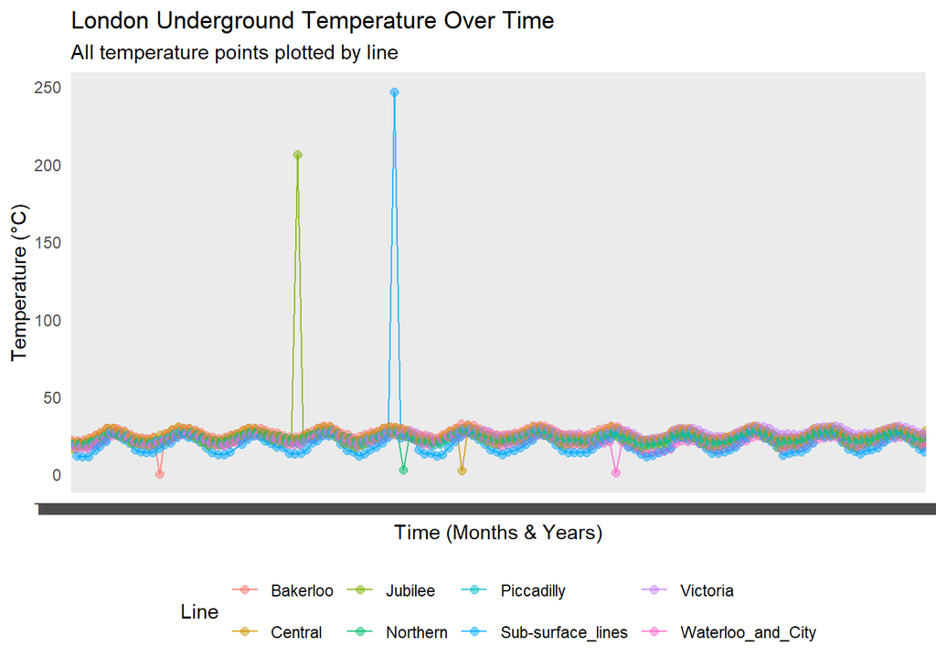

```r
# Plot a line graph to visually highlight potential outliers or anomalies in the dataset.
# This plot helps visualize the general seasonal trend and identify any data points that deviate significantly from that trend.
london_underground %>%
  drop_na(Temp) %>%
  ggplot(aes(x = ID, y = Temp, color = Line, group = Line)) +
  geom_line(alpha = 0.8) +
  geom_point(alpha = 0.5, size = 2) +
  labs(
    title = "London Underground Temperature Over Time",
    subtitle = "All temperature points plotted by line",
    x = "Time (Months & Years)",
    y = "Temperature (°C)",
    color = "Line"
  ) +
  theme_minimal() +
  theme(legend.position = "bottom")
```

The line graph above clearly shows six extreme data points. These points are visually distinct from the main cluster of data, which forms a uniform and continuous trend pattern across all months from 2013-2024. These six points appear to be outliers.

Furthermore, We plot the same line graph again below, but with the y-axis limited to a range of 5°C to 50°C. This change excludes the extreme outliers and ‘zooms in’ on the continuous, wave-like trend of the main data. This zoomed-in view helps confirm that the vast majority of temperature readings fall within this 5°C-50°C range.

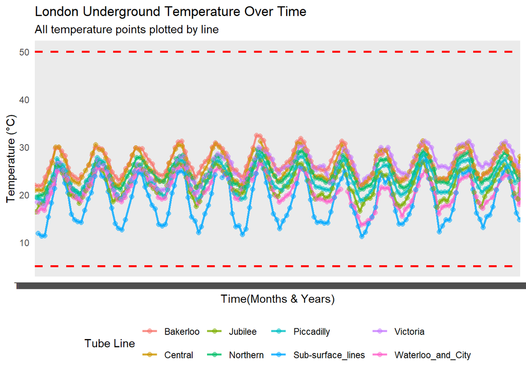

```r
# Re-plot the same time series, but zoom in on the main cluster of data by setting a fixed y-axis range from 5°C to 50°C
# This effectively 'cuts off' the extreme outliers identified in the previous plot,allowing for a clearer view of the seasonal pattern within the typical temperature range.
london_underground %>%
  drop_na(Temp) %>%
  ggplot(aes(x = ID, y = Temp, color = Line, group = Line)) +
  geom_line(alpha = 0.8 ,linewidth = 1) +
  geom_point(alpha = 0.5, size = 2) +
  geom_hline(yintercept = 50, linetype = "dashed", color = "red", linewidth = 1) +
  geom_hline(yintercept = 5, linetype = "dashed", color = "red", linewidth = 1) +
  labs(
    title = "London Underground Temperature Over Time",
    subtitle = "All temperature points plotted by line",
    x = "Time(Months & Years)",
    y = "Temperature (°C)",
    color = "Tube Line"
  ) +
  theme_minimal() +
    theme(legend.position = "bottom") +
  ylim(5,50) #Thus,We can now confirm that most of the temperature values falls within the range of 5-50°C (Indicated by the red dashed lines)
```

```r
#This small check is to confirm the count of outlier points lying outside the temperature range of 5°C-50°C by filtering the temperature values
(count_outliers <- sum((london_underground$Temp < 5 | london_underground$Temp > 50),
                       na.rm = TRUE))
```

```
## [1] 6
```

```r
# Identify and extract all temperature outliers (values below 5°C or above 50°C)
# This tibble shows the exact outlier values along with their corresponding year, month, and line
Outliers <- london_underground %>%
  filter(Temp < 5 | Temp > 50)
data.table(Outliers)
```

```
##          ID  Year     Month              Line   Temp
##      <char> <num>    <char>            <char>  <num>
## 1: TFL00121  2014     April          Bakerloo   0.27
## 2: TFL00307  2016     March           Jubilee 206.30
## 3: TFL00440  2017      July Sub-surface_lines 246.70
## 4: TFL00452  2017 September          Northern   2.74
## 5: TFL00530  2018      July           Central   2.32
## 6: TFL00735  2020    August Waterloo_and_City   1.05
```

To ensure the reliability of our temperature analysis, we have decided to exclude extreme values identified in the ‘Outliers’ tibble. These readings are likely due to data recording errors and fall outside the limits of normal operating conditions

- TFL00307 and TFL00440 recorded temperatures exceeding 100°C—above the boiling point of water and far beyond any feasible underground or human-safe environment.
- TFL00121, TFL00452, TFL00530, and TFL00735 registered temperatures near 0°C. For TFL00530 and TFL00735,these readings occurred during summer months, making such low extremes physically implausible and indicative of recording errors.

```r
# Create a cleaned tibble by excluding extreme temperature values
# Retain only observations where 'Temp' lies between 5°C and 50°C
# Remove rows with missing values (NA) to ensure reliable analysis
london_clean <- london_underground %>%
  filter(!is.na(Temp) & Temp >= 5 & Temp <= 50)
data.table(london_clean)
```

```
##             ID  Year    Month              Line  Temp
##         <char> <num>   <char>            <char> <num>
##    1: TFL00001  2013  January          Bakerloo 21.97
##    2: TFL00002  2013  January           Central 21.00
##    3: TFL00003  2013  January           Jubilee 16.40
##    4: TFL00004  2013  January          Northern 19.50
##    5: TFL00005  2013  January        Piccadilly 19.30
##   ---
## 1131: TFL01147  2024 December           Jubilee 19.10
## 1132: TFL01148  2024 December          Northern 23.20
## 1133: TFL01150  2024 December          Victoria 26.00
## 1134: TFL01151  2024 December Waterloo_and_City 17.90
## 1135: TFL01152  2024 December Sub-surface_lines 14.70
```

## Statistical Overview of London Underground Lines (All lines)

We calculate the key descriptive statistics for all lines present in the filtered dataset (london_clean), prior to any further filtering and analysis

```r
# Group the data by 'Line' to perform calculations on each line individually.
# We then use summarize() to calculate four key statistics:
#   1. mean_temperature: The average temperature.
#   2. std_dev_temperature: The standard deviation, a measure of temperature variability.
#   3. lowest_temperature: The minimum recorded temperature.
#   4. highest_temperature: The maximum recorded temperature.
 summary_table <- london_clean %>%
  group_by(`Line`) %>%
  summarize(
    mean_temperature = mean(Temp),
    std_dev_temperature = sd(Temp),
    lowest_temperature = min(Temp),
    highest_temperature = max(Temp)
  )
data.table(summary_table)
```

```
##                 Line mean_temperature std_dev_temperature lowest_temperature
##               <char>            <num>               <num>              <num>
## 1:          Bakerloo            26.82               2.611              21.77
## 2:           Central            26.11               2.865              20.90
## 3:           Jubilee            22.16               2.820              16.40
## 4:          Northern            24.72               2.456              19.50
## 5:        Piccadilly            23.32               2.742              18.70
## 6: Sub-surface_lines            18.74               4.531              11.18
## 7:          Victoria            25.65               3.192              17.70
## 8: Waterloo_and_City            21.02               2.951              13.69
##    highest_temperature
##                  <num>
## 1:               32.41
## 2:               31.32
## 3:               28.16
## 4:               29.46
## 5:               28.57
## 6:               27.72
## 7:               31.25
## 8:               26.54
```

## Data Preparation for plot visualization and t-test.

As per the project requirements,the “Sub‑surface_lines” category is excluded from the dataset to ensure the focus remains on deep‑level lines. A new tibble, london_deeplines, is created containing only temperature observations from these deep‑level lines. This cleaned dataset will serve as the basis for all subsequent visualizations and statistical comparisons, including the t‑tests.

```r
# Exclude all rows where 'Line' is classified as Sub-Surface-Lines
# Create a new tibble 'london_deeplines' containing only deep-level tube lines
london_deeplines <- london_clean %>%
   filter(Line != "Sub-surface_lines")
data.table(london_deeplines)
```

```
##            ID  Year    Month              Line  Temp
##        <char> <num>   <char>            <char> <num>
##   1: TFL00001  2013  January          Bakerloo 21.97
##   2: TFL00002  2013  January           Central 21.00
##   3: TFL00003  2013  January           Jubilee 16.40
##   4: TFL00004  2013  January          Northern 19.50
##   5: TFL00005  2013  January        Piccadilly 19.30
##  ---
## 989: TFL01146  2024 December           Central 24.70
## 990: TFL01147  2024 December           Jubilee 19.10
## 991: TFL01148  2024 December          Northern 23.20
## 992: TFL01150  2024 December          Victoria 26.00
## 993: TFL01151  2024 December Waterloo_and_City 17.90
```

We will use the london_deeplines tibble for all subsequent analysis and visualizations, as it represents the final cleaned dataset with outliers, missing values, and sub‑surface lines removed.

## Statistical Overview of London Underground Lines (All lines - excluding sub-surface lines)

This table presents the statistical overview of London Underground deep‑level lines, excluding the sub‑surface category. It summarizes the mean and standard deviation of recorded temperatures for each line, providing a clear basis for subsequent plot visualization and t‑test analysis.

```r
# Compute summary statistics for each London Underground line in 'london_deeplines'
# Calculate the mean and standard deviation of recorded temperatures
# Store results in 'summary_final' for use in subsequent t-test analysis and visualization
summary_final <- london_deeplines %>%
  group_by(`Line`) %>%
  summarize(
    mean_temperature_plot = mean(Temp),
    std_dev_temperature_plot = sd(Temp)
  )
data.table(summary_final)
```

```
##                 Line mean_temperature_plot std_dev_temperature_plot
##               <char>                 <num>                    <num>
## 1:          Bakerloo                 26.82                    2.611
## 2:           Central                 26.11                    2.865
## 3:           Jubilee                 22.16                    2.820
## 4:          Northern                 24.72                    2.456
## 5:        Piccadilly                 23.32                    2.742
## 6:          Victoria                 25.65                    3.192
## 7: Waterloo_and_City                 21.02                    2.951
```

We present the violin plot of the filtered dataset (london_deeplines) to show monthly temperature distributions across individual Underground lines.Violin plot is used instead of histogram as they provide a smooth density representation and allow direct comparison across multiple categories in a compact format. To improve interpretability, the plots also overlay the mean temperature (point) and ±1 standard deviation (error bars), highlighting both central tendency and variability.

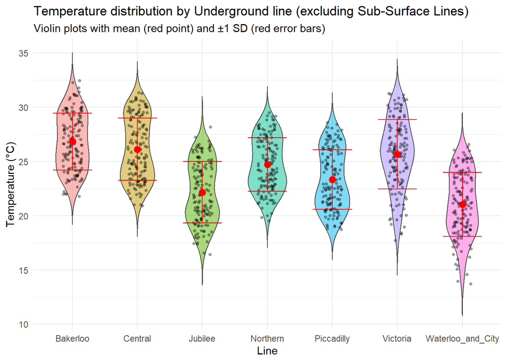

```r
# Create violin plot of temperature distributions by Deep Underground line
# - Violin plot show the full distribution of recorded temperatures
# - Jittered points represent individual observations
# - Red points indicate mean temperature per line
# - Red error bars represent ±1 standard deviation around the mean
(temperature_plot <- ggplot(london_deeplines, aes(x = Line, y = Temp, fill = Line)) +
  geom_violin(trim = FALSE, width = 0.6, scale = "count",alpha = 0.5, color = "grey30") +
  geom_jitter(width = 0.15, alpha = 0.35, size = 1, color = "black") +
  geom_point(data = summary_final, aes(x = Line, y = mean_temperature_plot), color = "red", size = 3, inherit.aes = FALSE) +
  geom_errorbar(
    data = summary_final,
    aes(x = Line, ymin = mean_temperature_plot - std_dev_temperature_plot, ymax = mean_temperature_plot + std_dev_temperature_plot),
    width = 0.6, color = "red", inherit.aes = FALSE
  ) +
  labs(
    title = "Temperature distribution by Underground line (excluding Sub-Surface Lines)",
    subtitle = "Violin plots with mean (red point) and ±1 SD (red error bars)",
    x = "Line",
    y = "Temperature (°C)"
  ) +
  theme_minimal() +
  theme(legend.position = "none"))
```

## T‑Test Comparison of Bakerloo vs Central Line Temperatures(All months)

```r
# Create a new tibble 'bakerloo_temp' by subsetting the main dataset (london_deeplines)
# This tibble allows for direct statistical comparison with Central line in subsequent T-test.
bakerloo_temp <- london_deeplines %>%
  filter(grepl("Bakerloo",Line))
data.table(bakerloo_temp)
```

```
##            ID  Year     Month     Line  Temp
##        <char> <num>    <char>   <char> <num>
##   1: TFL00001  2013   January Bakerloo 21.97
##   2: TFL00009  2013  February Bakerloo 21.77
##   3: TFL00017  2013     March Bakerloo 21.97
##   4: TFL00025  2013     April Bakerloo 23.67
##   5: TFL00033  2013       May Bakerloo 25.40
##  ---
## 139: TFL01113  2024    August Bakerloo 29.90
## 140: TFL01121  2024 September Bakerloo 29.27
## 141: TFL01129  2024   October Bakerloo 27.77
## 142: TFL01137  2024  November Bakerloo 26.47
## 143: TFL01145  2024  December Bakerloo 25.47
```

```r
# Create a another new tibble 'Central' by subsetting the main dataset (london_deeplines)
# This tibble allows for direct statistical comparison with Bakerloo Line in subsequent T-test.
Central_temp <- london_deeplines %>%
  filter(grepl("Central",Line))
data.table(Central_temp)
```

```
##            ID  Year     Month    Line  Temp
##        <char> <num>    <char>  <char> <num>
##   1: TFL00002  2013   January Central  21.0
##   2: TFL00010  2013  February Central  21.0
##   3: TFL00018  2013     March Central  20.9
##   4: TFL00026  2013     April Central  22.8
##   5: TFL00034  2013       May Central  24.7
##  ---
## 139: TFL01114  2024    August Central  30.6
## 140: TFL01122  2024 September Central  29.1
## 141: TFL01130  2024   October Central  27.5
## 142: TFL01138  2024  November Central  26.1
## 143: TFL01146  2024  December Central  24.7
```

```r
# Perform an independent two-sample t-test
# Compare the mean 'Temp' values between two subsets:
#   1. Central line observations
#   2. Bakerloo line observations
# The function t.test() automatically handles unequal variances (Welch’s t-test)
# Output includes the test statistic, degrees of freedom, p-value,
# and confidence interval for the difference in means
(t_test_all_months <- t.test(bakerloo_temp$Temp,Central_temp$Temp))
```

```
##
##  Welch Two Sample t-test
##
## data:  bakerloo_temp$Temp and Central_temp$Temp
## t = 2.2, df = 282, p-value = 0.03
## alternative hypothesis: true difference in means is not equal to 0
## 95 percent confidence interval:
##  0.06768 1.34379
## sample estimates:
## mean of x mean of y
##     26.82     26.11
```

## T‑Test Comparison of Bakerloo vs Central Line Temperatures(Only in the summer months)

As before, the t-test compares the mean values from two independent groups, but here the subsets are limited to summer months (May-August).This approach helps decision makers determine whether higher summer temperatures increase the disparity between the two lines, offering clear evidence to guide cooling system installation during peak demand.

```r
# Define the set of months considered as "summer"

summer_months <- c("May", "June", "July", "August")

# Subset Bakerloo line data to retain only rows where 'Month' is in summer_months

bakerloo_temp_summer <- bakerloo_temp %>%
  filter(Month %in% summer_months)
data.table(bakerloo_temp_summer)
```

```
##           ID  Year  Month     Line  Temp
##       <char> <num> <char>   <char> <num>
##  1: TFL00033  2013    May Bakerloo 25.40
##  2: TFL00041  2013   June Bakerloo 27.00
##  3: TFL00049  2013   July Bakerloo 29.70
##  4: TFL00057  2013 August Bakerloo 29.90
##  5: TFL00129  2014    May Bakerloo 26.10
##  6: TFL00137  2014   June Bakerloo 28.30
##  7: TFL00145  2014   July Bakerloo 29.90
##  8: TFL00153  2014 August Bakerloo 29.80
##  9: TFL00225  2015    May Bakerloo 26.41
## 10: TFL00233  2015   June Bakerloo 28.17
## 11: TFL00241  2015   July Bakerloo 29.78
## 12: TFL00249  2015 August Bakerloo 29.62
## 13: TFL00321  2016    May Bakerloo 26.61
```

[output cut: 36 more lines]

```r
# Subset Central line data in the same way, isolating summer_months observations

central_temp_summer <- Central_temp %>%
  filter(Month %in% summer_months)

data.table(central_temp_summer)
```

```
##           ID  Year  Month    Line  Temp
##       <char> <num> <char>  <char> <num>
##  1: TFL00034  2013    May Central 24.70
##  2: TFL00042  2013   June Central 26.70
##  3: TFL00050  2013   July Central 30.00
##  4: TFL00058  2013 August Central 30.00
##  5: TFL00130  2014    May Central 26.30
##  6: TFL00138  2014   June Central 28.70
##  7: TFL00146  2014   July Central 30.50
##  8: TFL00154  2014 August Central 29.50
##  9: TFL00226  2015    May Central 26.32
## 10: TFL00234  2015   June Central 28.37
## 11: TFL00242  2015   July Central 29.81
## 12: TFL00250  2015 August Central 29.43
## 13: TFL00322  2016    May Central 26.62
```

[output cut: 35 more lines]

```r
# Compare the mean 'Temp' values between two subsets:
#   1. Central line observations
#   2. Bakerloo line observations
# The function t.test() automatically handles unequal variances (Welch’s t-test)
# Output includes the test statistic, degrees of freedom, p-value,
# and confidence interval for the difference in means

(t_test_summer_months <- t.test(bakerloo_temp_summer$Temp,
                               central_temp_summer$Temp))
```

```
##
##  Welch Two Sample t-test
##
## data:  bakerloo_temp_summer$Temp and central_temp_summer$Temp
## t = 0.16, df = 93, p-value = 0.9
## alternative hypothesis: true difference in means is not equal to 0
## 95 percent confidence interval:
##  -0.6908  0.8103
## sample estimates:
## mean of x mean of y
##     28.74     28.68
```

# Section 2

## Overview

This section presents the results of the statistical analysis of London Underground temperature data. The analysis focuses on deep‑level lines, as sub‑surface lines were excluded to ensure comparability. Outliers and missing values were removed to improve reliability, leaving a clean dataset (london_deeplines) for analysis. The findings are reported using standard statistical conventions, but are also explained in plain English to highlight their practical implications for decision‑making.

## Descriptive Statistics

Table 1 below summarises the mean and standard deviation of recorded temperatures for each deep‑level line. These figures provide an overview of the typical conditions passengers experience and the variability across lines.

Table 1. Summary of Mean and Standard Deviation of Temperatures by Line

| Line | mean_temperature_plot | std_dev_temperature_plot |
| --- | --- | --- |
| Bakerloo | 26.82 | 2.61 |
| Central | 26.11 | 2.86 |
| Jubilee | 22.16 | 2.82 |
| Northern | 24.72 | 2.46 |
| Piccadilly | 23.32 | 2.74 |
| Victoria | 25.65 | 3.19 |
| Waterloo_and_City | 21.02 | 2.95 |

## Statistical Testing

#### 2. Summer Months (May–August)

- The Welch Two‑Sample t‑test produced t(92.98) = 0.16, p = 0.875. Because the p‑value is far above the conventional threshold of 0.05, we conclude that there is no statistically significant difference in mean temperatures between the Bakerloo and Central lines during the summer months.
- The Bakerloo line has an average temperature of 28.74 °C compared to 28.68 °C on the Central line — a difference of only about 0.06 °C. The 95% confidence interval (‑0.69 to 0.81 °C) spans both negative and positive values, indicating that the true difference could be slightly cooler or slightly warmer on Bakerloo, but is effectively negligible.
- In summer, both lines converge at similarly high temperatures. The lack of a meaningful difference suggests that seasonal heat dominates, masking any underlying variation between the lines. Passengers therefore experience equally high levels of heat stress on both Bakerloo and Central during peak summer months.

#### Intepretation:

- **Year‑round** : Targeted air cooling system installment may be most beneficial on the Bakerloo Line, where passengers consistently face higher temperatures.
- **Summer** : System‑wide strategies are required, as all lines converge at equally high levels of heat stress.

In short, Bakerloo’s “extra warmth” matters outside of summer, but in peak heat periods, all passengers across both lines face similar challenges, highlighting the need for both line‑specific interventions and network‑wide summer resilience measure.

## Visualisations

Figure 1. illustrate the distribution of temperatures across deep underground lines in each year. Violin plot is used to highlight both the central tendency and the spread of values.

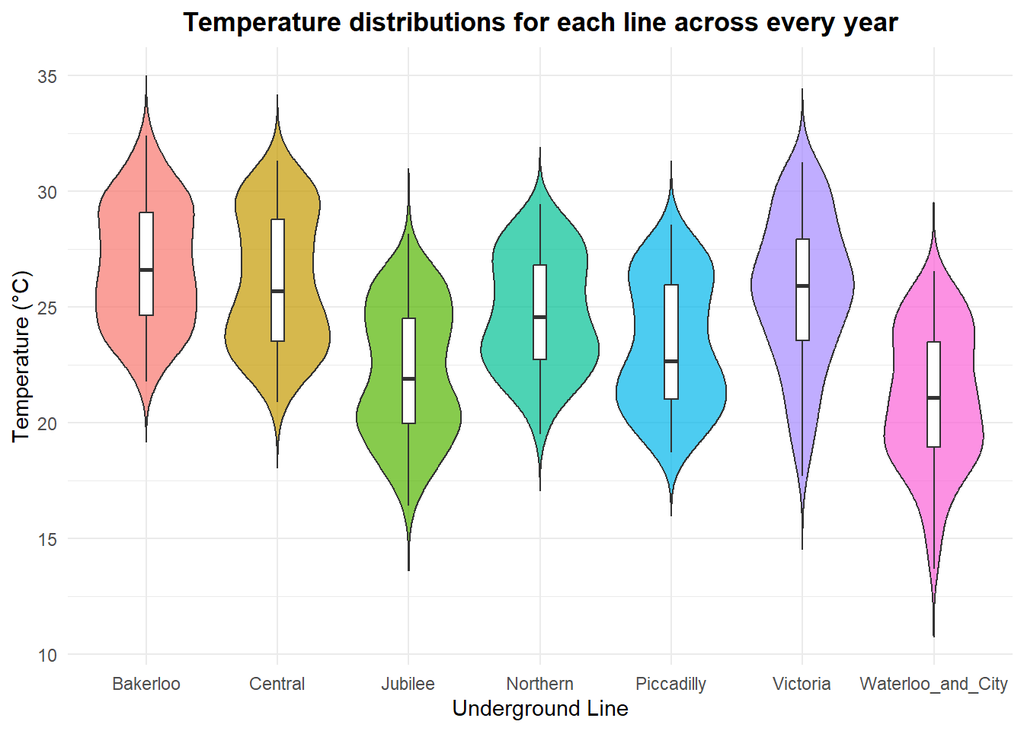

Figure 1. Temperature Distributions by Line

## Conclusion

The analysis demonstrates that temperature conditions vary significantly across deep‑level lines. Bakerloo is hotter than Central across the year, but both lines converge at equally high temperatures in summer. By prioritising cooling interventions on these lines, Transport for London can make data‑driven decisions that maximise passenger comfort and operational resilience.

## Reference

- (Transport for London. (2022) Referencing. [online] Available from: https://tfl.gov.uk/info-for/media/press-releases/2022/july/tfl-trials-innovative-cooling-solution-designed-to-reduce-temperatures-on-the-tube-network# (Accessed 06 Nov 2025)